# Analisis ARDL SKRIPSI

## 3.2 Time Series

### 3.2.1 Plot Time Series TMA

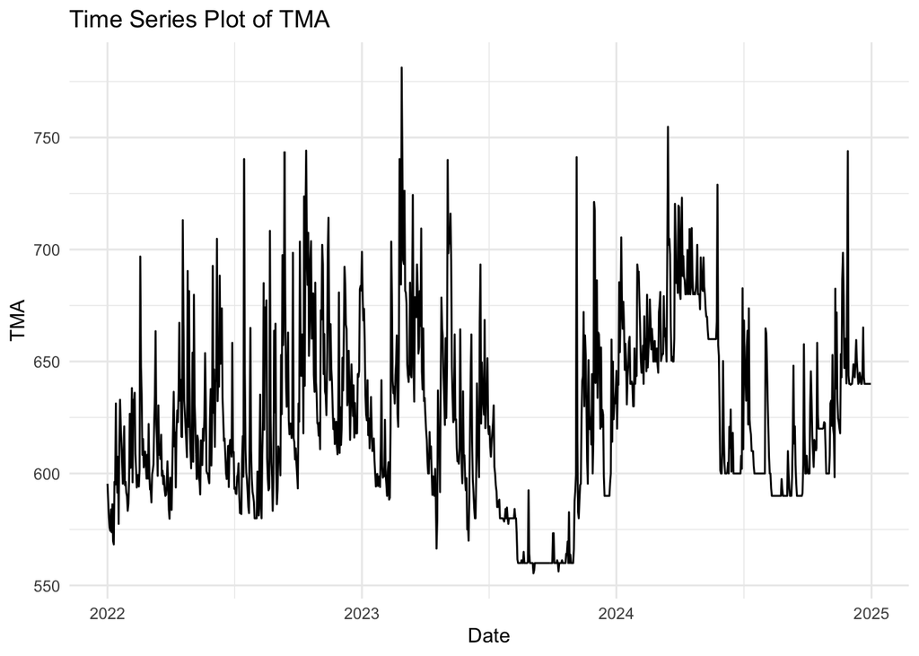

```r
ggplot(data = dataset, aes(x = Date, y = TMA)) +
  geom_line() +
  labs(title = "Time Series Plot of TMA", x = "Date", y = "TMA") +
  theme_minimal()
```

### 3.2.2 Plot Time Series PC

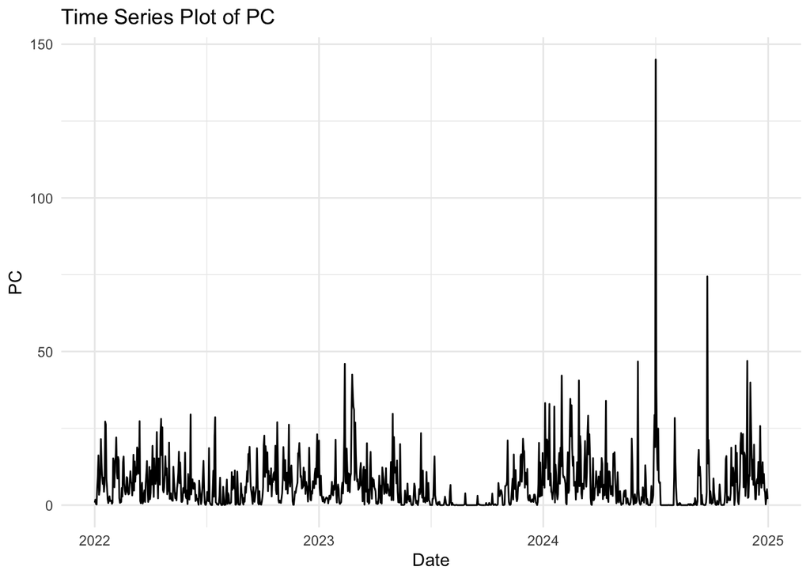

```r
ggplot(data = dataset, aes(x = Date, y = PC)) +
  geom_line() +
  labs(title = "Time Series Plot of PC", x = "Date", y = "PC") +
  theme_minimal()
```

### 3.2.3 Plot Time Series TM

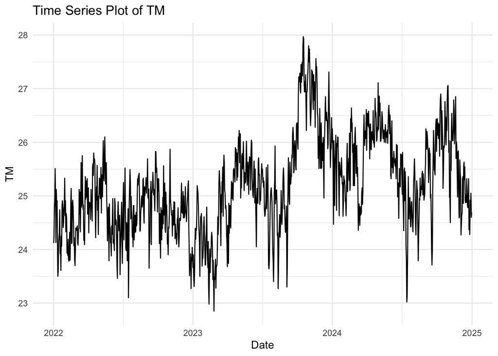

```r
ggplot(data = dataset, aes(x = Date, y = TM)) +
  geom_line() +
  labs(title = "Time Series Plot of TM", x = "Date", y = "TM") +
  theme_minimal()
```

### 3.2.4 Plot Time Series RH

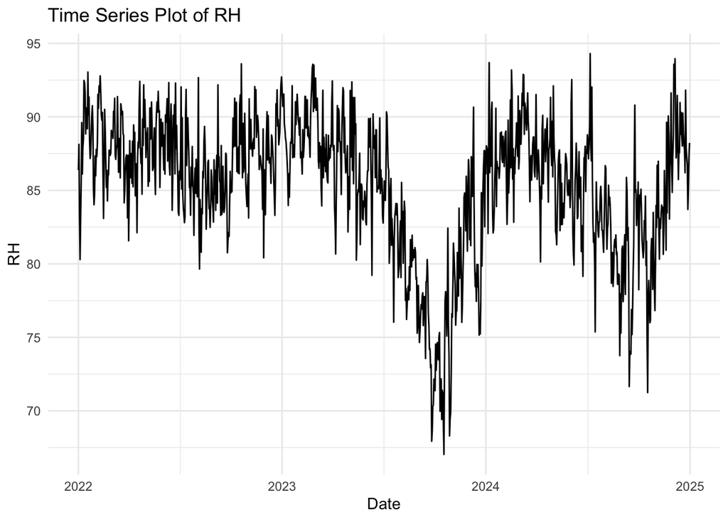

```r
ggplot(data = dataset, aes(x = Date, y = RH)) +
  geom_line() +
  labs(title = "Time Series Plot of RH", x = "Date", y = "RH") +
  theme_minimal()
```

### 3.2.5 Plot Time Series WS

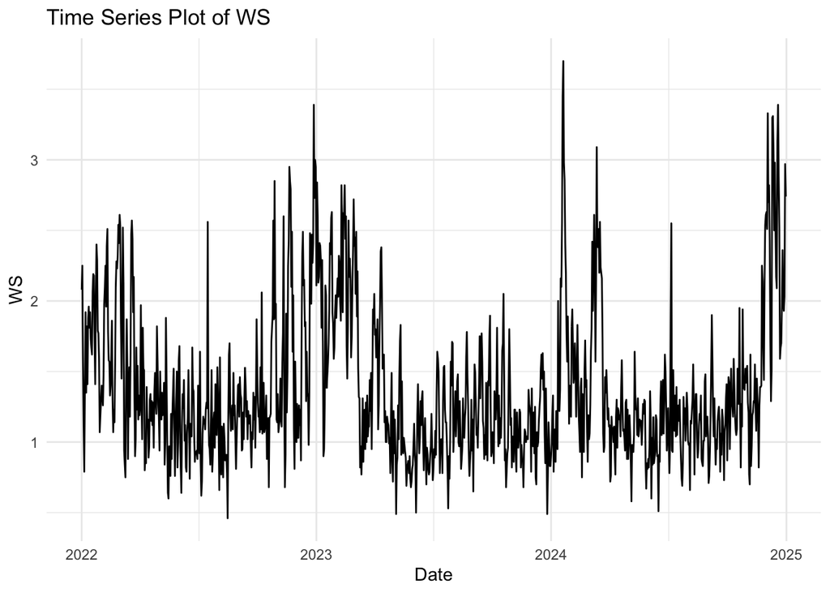

```r
ggplot(data = dataset, aes(x = Date, y = WS)) +
  geom_line() +
  labs(title = "Time Series Plot of WS", x = "Date", y = "WS") +
  theme_minimal()
```

### 3.2.6 Plot Time Series Gabungan

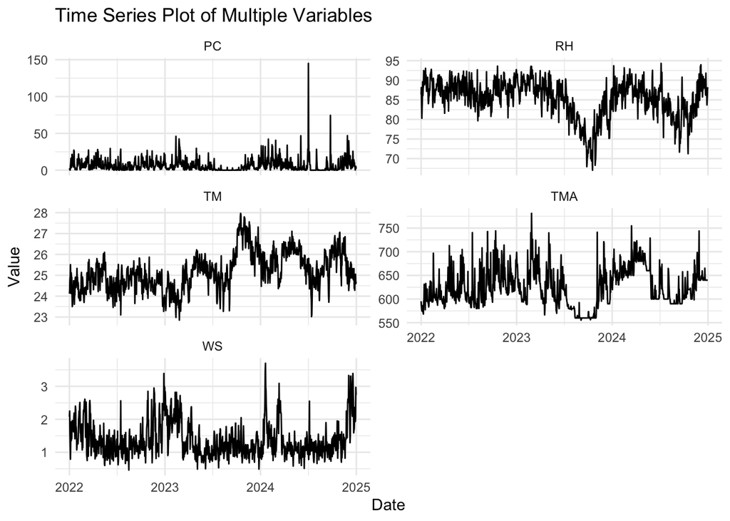

```r
# Ubah data menjadi long format
data_long <- dataset %>%
  pivot_longer(cols = c(TMA, PC, TM, RH, WS),
               names_to = "Variabel",
               values_to = "Nilai")

# Membuat plot dengan facet_wrap
ggplot(data_long, aes(x = Date, y = Nilai)) +
  geom_line() +
  facet_wrap(~ Variabel, scales = "free_y", ncol = 2) +
  labs(title = "Time Series Plot of Multiple Variables",
       x = "Date",
       y = "Value") +
  theme_minimal()
```

## 3.3 Matriks Korelasi

```r
cor_matrix <- cor(dataset[, c("TMA", "PC", "TM", "RH", "WS")], use = "complete.obs")
cor_matrix
```

```
##             TMA         PC          TM         RH         WS
## TMA  1.00000000  0.3945932 -0.03538558  0.5250838  0.1242238
## PC   0.39459319  1.0000000 -0.11754806  0.4196228  0.1232182
## TM  -0.03538558 -0.1175481  1.00000000 -0.4854181 -0.3997199
## RH   0.52508382  0.4196228 -0.48541808  1.0000000  0.3378856
## WS   0.12422384  0.1232182 -0.39971987  0.3378856  1.0000000
```

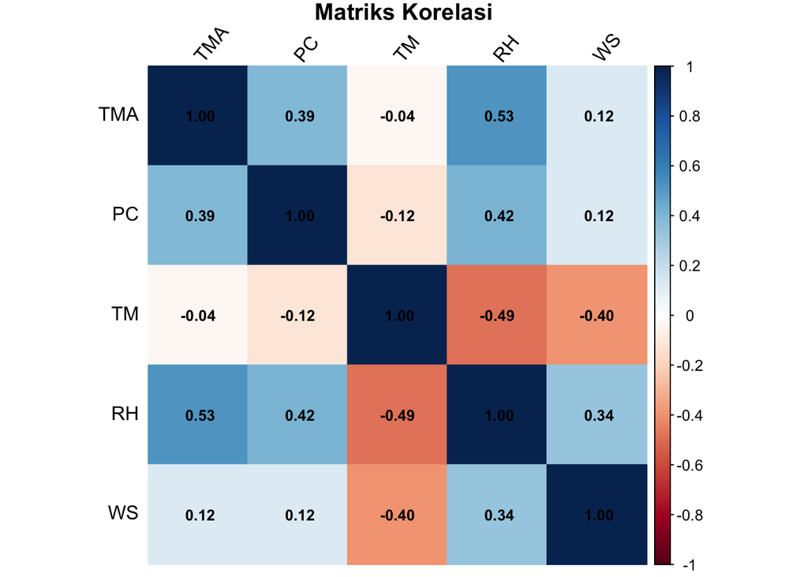

```r
corrplot(cor_matrix, method = "color", addCoef.col = "black",
         tl.col = "black", tl.srt = 50, number.cex = 0.8,
         title = "Matriks Korelasi",
         mar = c(0,0,1,0))
```

- TMA memiliki korelasi positif dengan peubah penjelas PC sebesar 0,39 dan peubah penjelas RH sebesar 0,53. Hal ini berarti jika peubah penjelas PC atau RH meningkat maka TMA juga cenderung meningkat.
- Korelasi antara peubah penjelas TMA dengan peubah penjelas TM dan WS relatif sangat lemah, artinya perubahan TM atau WS tidak terlalu berperan langsung dalam memengaruhi TMA.

# 4 Data Splitting

```r
total_rows <- 1096
test_size <- 160

train_index <- 1:(total_rows - test_size)
test_index  <- (total_rows - test_size + 1):total_rows

train_2225 <- dataset[train_index, ]
test_2225  <- dataset[test_index, ]
str(train_2225)
```

```
## tibble [936 × 6] (S3: tbl_df/tbl/data.frame)
##  $ Date: POSIXct[1:936], format: "2022-01-01" "2022-01-02" ...
##  $ TMA : num [1:936] 595 588 580 576 574 ...
##  $ TM  : num [1:936] 24.1 24.2 24.8 24.9 25.5 ...
##  $ PC  : num [1:936] 0.85 1.79 0.4 0.22 5.7 ...
##  $ RH  : num [1:936] 86.4 88.1 83.2 80.3 83.2 ...
##  $ WS  : num [1:936] 2.08 2.25 1.56 1.11 0.79 1.38 1.92 1.35 1.82 1.41 ...
```

```r
str(test_2225)
```

```
## tibble [160 × 6] (S3: tbl_df/tbl/data.frame)
##  $ Date: POSIXct[1:160], format: "2024-07-25" "2024-07-26" ...
##  $ TMA : num [1:160] 600 600 600 600 600 ...
##  $ TM  : num [1:160] 24.4 24.9 24.9 24.7 24.5 ...
##  $ PC  : num [1:160] 0.01 0.01 0 0 0 ...
##  $ RH  : num [1:160] 85.3 84.4 82.3 82.3 81.6 ...
##  $ WS  : num [1:160] 1.32 1.13 1.24 1.01 1.16 1.35 1.25 1.01 0.98 0.99 ...
```

```r
train_2225.ts<-ts(train_2225)
test_2225.ts<-ts(test_2225)
```

## 4.1 Time series data split

```r
train_2225 <- train_2225 %>%
  mutate(DataType = "Train")

test_2225 <- test_2225 %>%
  mutate(DataType = "Test")
```

### 4.1.1 Plot Time Series TMA

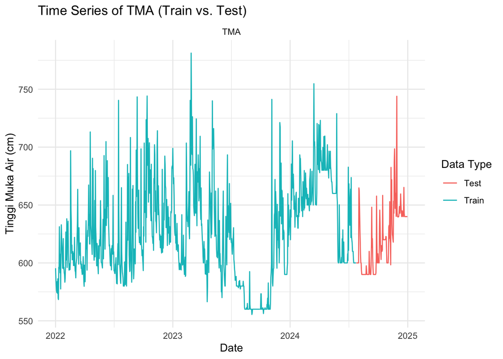

```r
combined_data <- bind_rows(train_2225, test_2225)
data_long <- combined_data %>%
  pivot_longer(cols = c(TMA),
               names_to = "Variabel",
               values_to = "Nilai")

ggplot(data_long, aes(x = Date, y = Nilai, color = DataType)) +
  geom_line() +
  facet_wrap(~ Variabel, scales = "free_y", ncol = 2) +
  scale_color_manual(values = c("Train" = "#00BFC4", "Test" = "#F8766D")) +
  labs(title = "Time Series of TMA (Train vs. Test)",
       x = "Date",
       y = "Tinggi Muka Air (cm)",
       color = "Data Type") +
  theme_minimal()
```

### 4.1.2 Plot Time Series PC

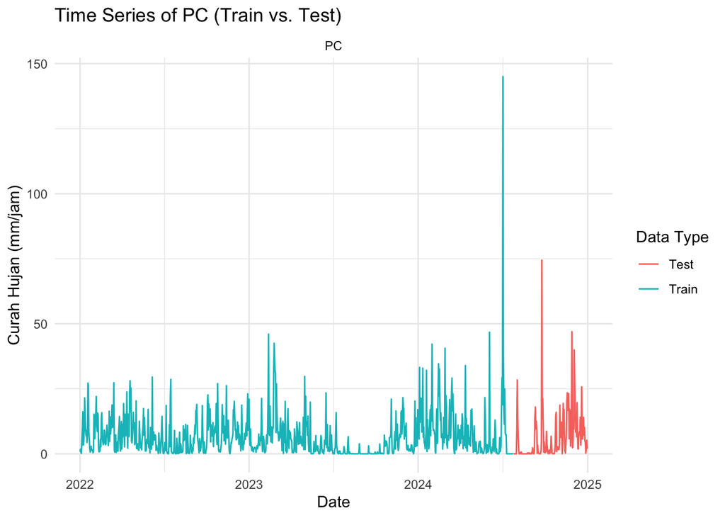

```r
combined_data <- bind_rows(train_2225, test_2225)
data_long <- combined_data %>%
  pivot_longer(cols = c(PC),
               names_to = "Variabel",
               values_to = "Nilai")

ggplot(data_long, aes(x = Date, y = Nilai, color = DataType)) +
  geom_line() +
  facet_wrap(~ Variabel, scales = "free_y", ncol = 2) +
  scale_color_manual(values = c("Train" = "#00BFC4", "Test" = "#F8766D")) +
  labs(title = "Time Series of PC (Train vs. Test)",
       x = "Date",
       y = "Curah Hujan (mm/jam)",
       color = "Data Type") +
  theme_minimal()
```

### 4.1.3 Plot Time Series TM

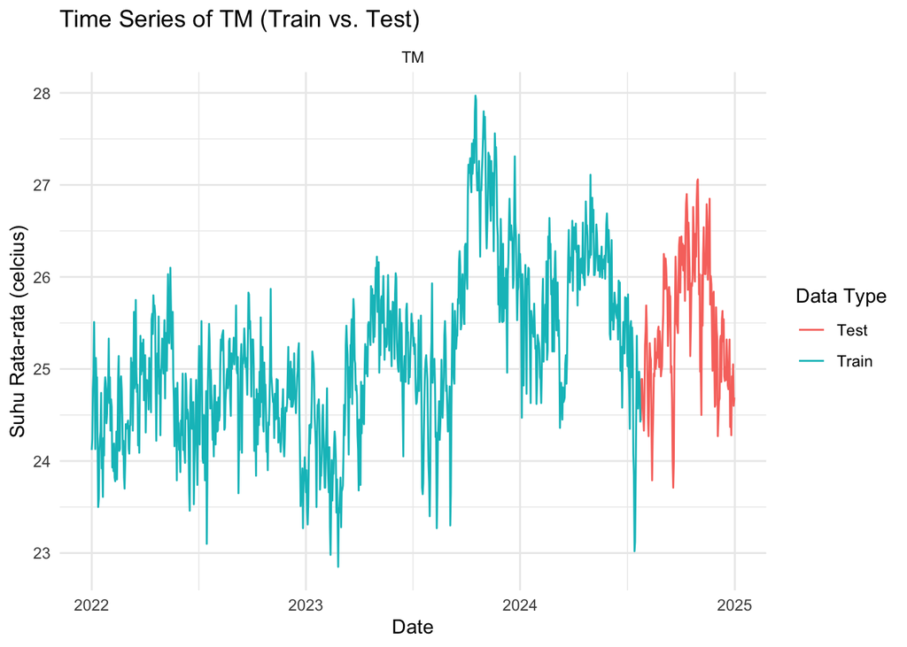

```r
combined_data <- bind_rows(train_2225, test_2225)
data_long <- combined_data %>%
  pivot_longer(cols = c(TM),
               names_to = "Variabel",
               values_to = "Nilai")

ggplot(data_long, aes(x = Date, y = Nilai, color = DataType)) +
  geom_line() +
  facet_wrap(~ Variabel, scales = "free_y", ncol = 2) +
  scale_color_manual(values = c("Train" = "#00BFC4", "Test" = "#F8766D")) +
  labs(title = "Time Series of TM (Train vs. Test)",
       x = "Date",
       y = "Suhu Rata-rata (celcius)",
       color = "Data Type") +
  theme_minimal()
```

### 4.1.4 Plot Time Series RH

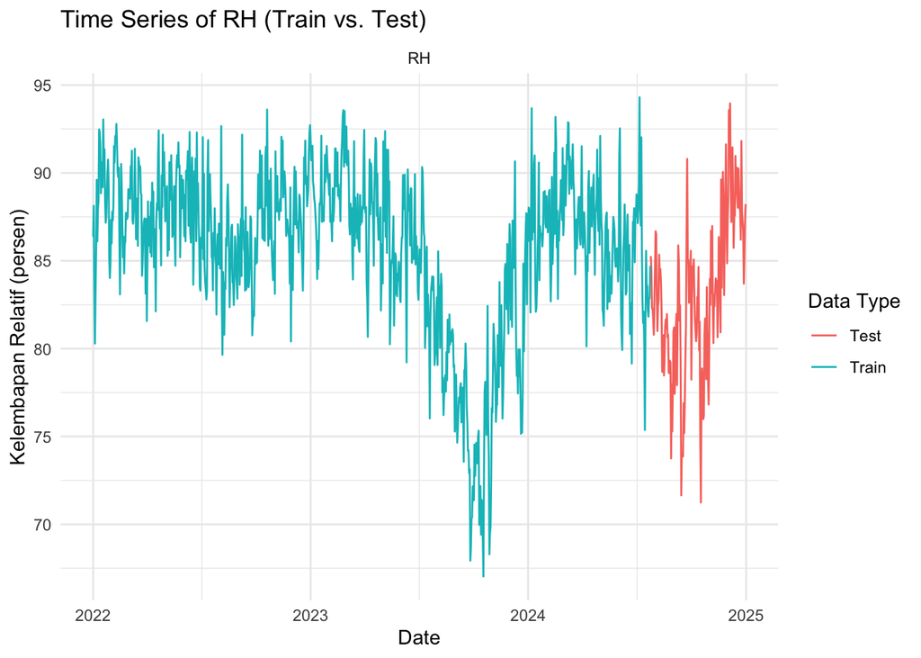

```r
combined_data <- bind_rows(train_2225, test_2225)
data_long <- combined_data %>%
  pivot_longer(cols = c(RH),
               names_to = "Variabel",
               values_to = "Nilai")

ggplot(data_long, aes(x = Date, y = Nilai, color = DataType)) +
  geom_line() +
  facet_wrap(~ Variabel, scales = "free_y", ncol = 2) +
  scale_color_manual(values = c("Train" = "#00BFC4", "Test" = "#F8766D")) +
  labs(title = "Time Series of RH (Train vs. Test)",
       x = "Date",
       y = "Kelembapan Relatif (persen)",
       color = "Data Type") +
  theme_minimal()
```

### 4.1.5 Plot Time Series WS

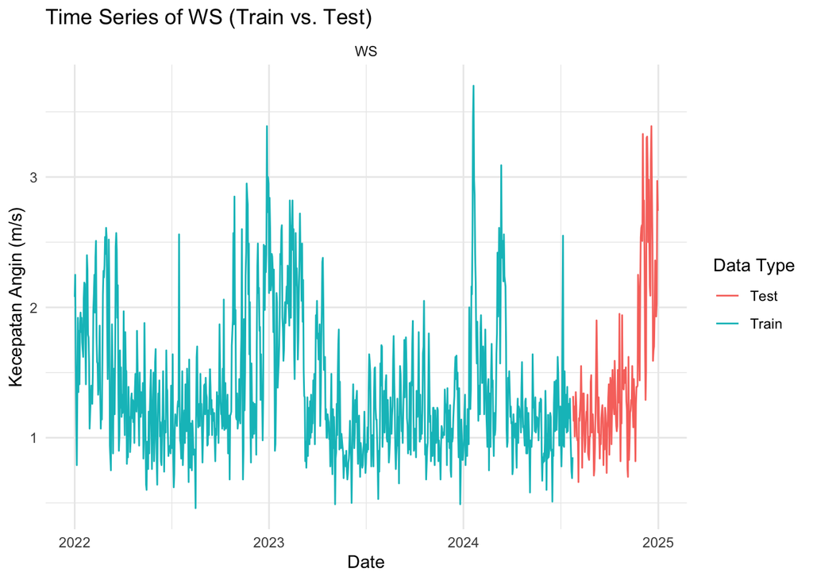

```r
combined_data <- bind_rows(train_2225, test_2225)
data_long <- combined_data %>%
  pivot_longer(cols = c(WS),
               names_to = "Variabel",
               values_to = "Nilai")

ggplot(data_long, aes(x = Date, y = Nilai, color = DataType)) +
  geom_line() +
  facet_wrap(~ Variabel, scales = "free_y", ncol = 2) +
  scale_color_manual(values = c("Train" = "#00BFC4", "Test" = "#F8766D")) +
  labs(title = "Time Series of WS (Train vs. Test)",
       x = "Date",
       y = "Kecepatan Angin (m/s)",
       color = "Data Type") +
  theme_minimal()
```

### 4.1.6 Plot Time Series Gabungan

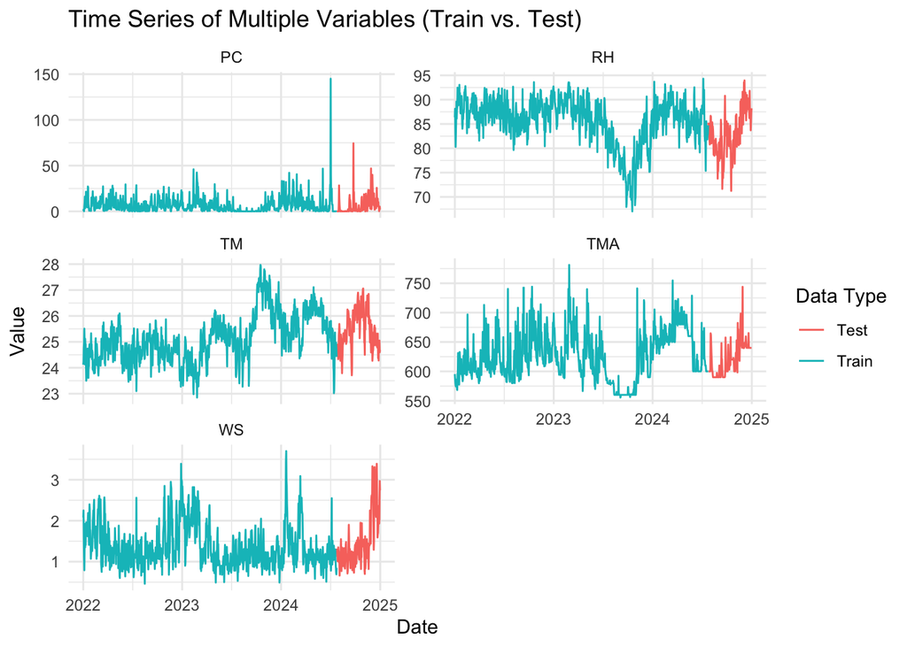

```r
combined_data <- bind_rows(train_2225, test_2225)
data_long <- combined_data %>%
  pivot_longer(cols = c(TMA, PC, TM, RH, WS),
               names_to = "Variabel",
               values_to = "Nilai")

ggplot(data_long, aes(x = Date, y = Nilai, color = DataType)) +
  geom_line() +
  facet_wrap(~ Variabel, scales = "free_y", ncol = 2) +
  scale_color_manual(values = c("Train" = "#00BFC4", "Test" = "#F8766D")) +
  labs(title = "Time Series of Multiple Variables (Train vs. Test)",
       x = "Date",
       y = "Value",
       color = "Data Type") +
  theme_minimal()
```

# 5 Kestasioneran Data

## 5.1 Plot ACF

### 5.1.1 Plot ACF TMA

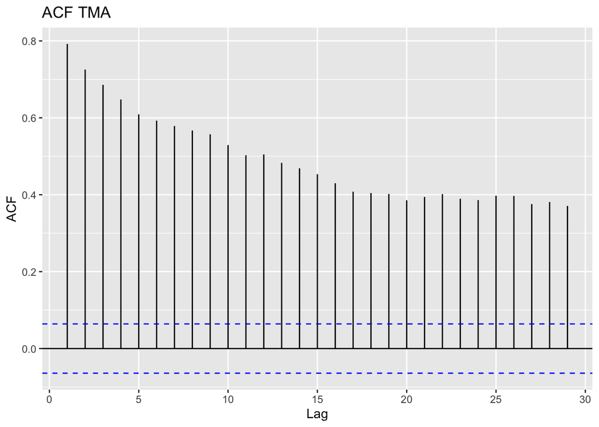

```r
acf_TMA <- ggAcf(train_2225$TMA) + labs(title = "ACF TMA")
acf_TMA
```

- Plot ACF TMA menurun secara perlahan : TMA tidak stasioner

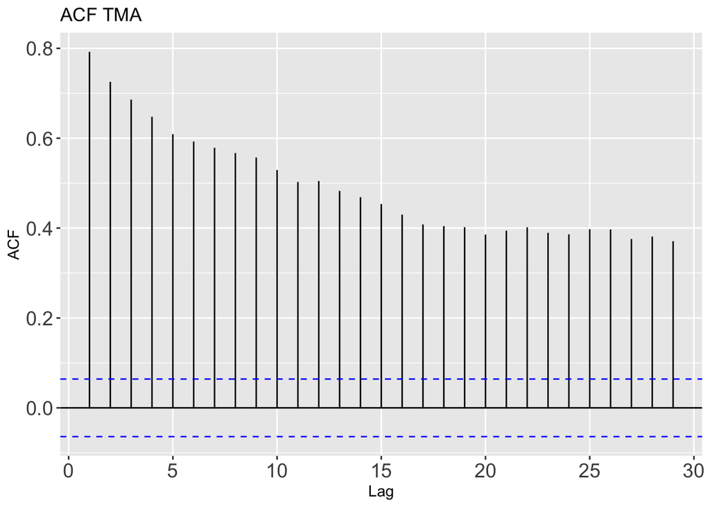

```r
acf_TMA <- ggAcf(train_2225$TMA) +
  labs(title = "ACF TMA") +
  theme(
    axis.text.x = element_text(size = 14),
    axis.text.y = element_text(size = 14)
  )
acf_TMA
```

### 5.1.2 Plot ACF PC

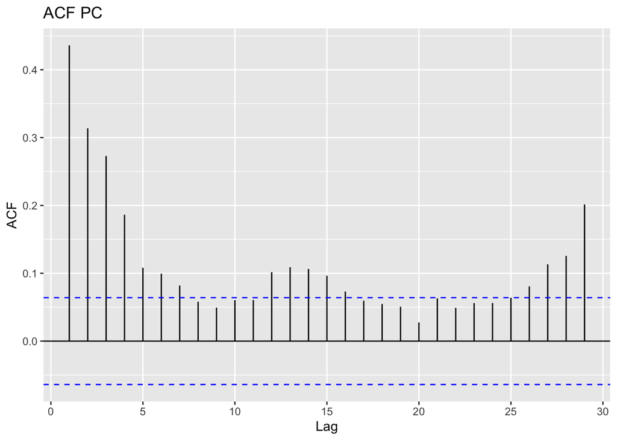

```r
acf_PC <- ggAcf(train_2225$PC) + labs(title = "ACF PC")
acf_PC
```

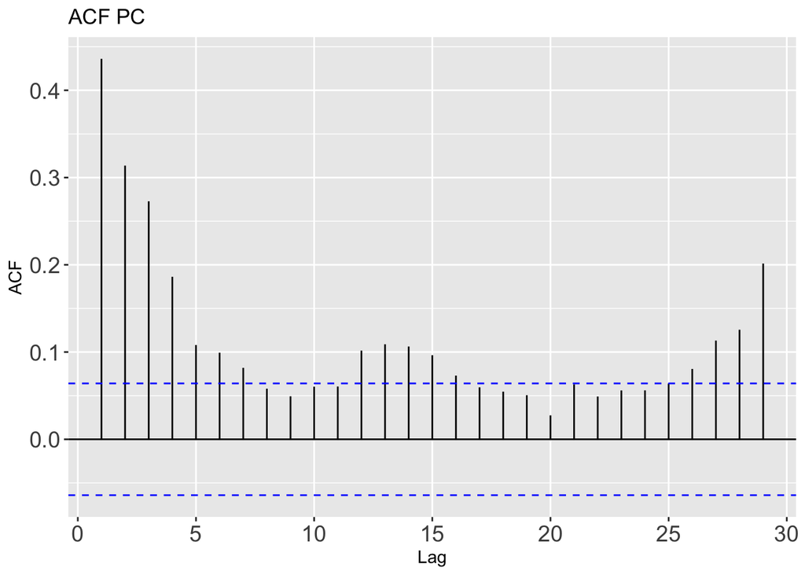

```r
acf_PC <- ggAcf(train_2225$PC) +
  labs(title = "ACF PC") +
  theme(
    axis.text.x = element_text(size = 14),
    axis.text.y = element_text(size = 14)
  )
acf_PC
```

### 5.1.3 Plot ACF TM

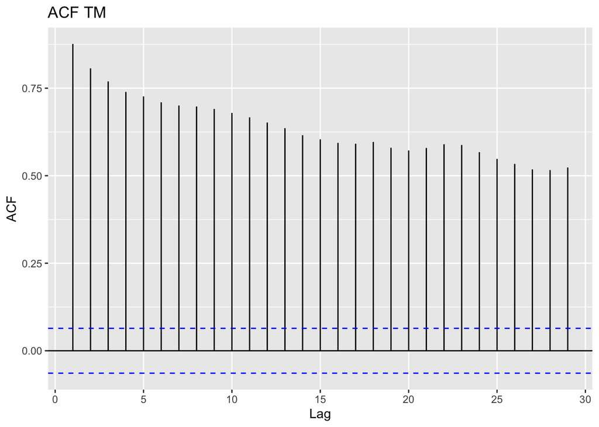

```r
acf_TM <- ggAcf(train_2225$TM) + labs(title = "ACF TM")
acf_TM
```

- Plot ACF TM menurun secara perlahan : TM tidak stasioner

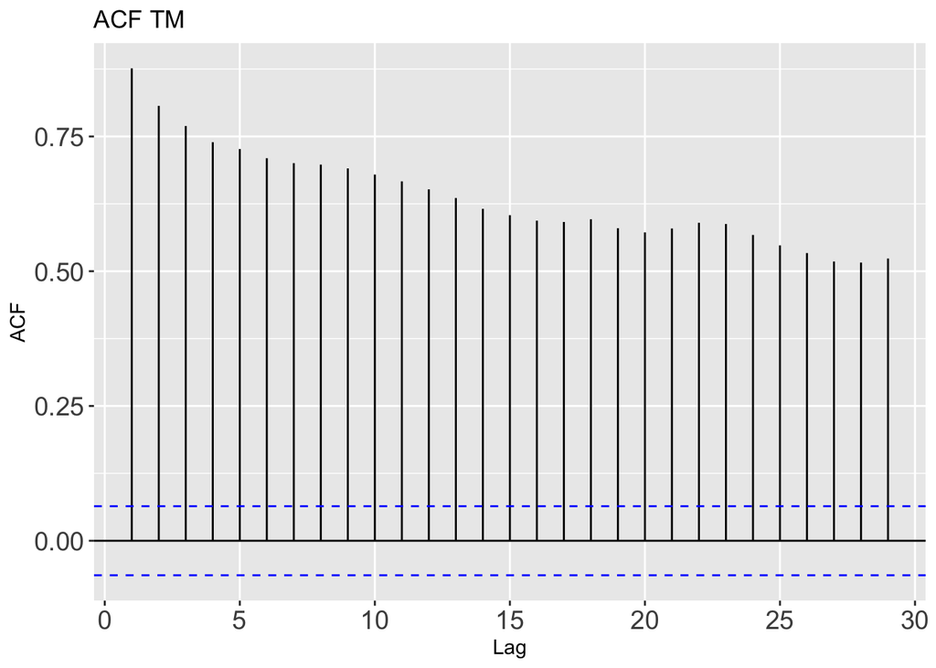

```r
acf_TM <- ggAcf(train_2225$TM) +
  labs(title = "ACF TM") +
  theme(
    axis.text.x = element_text(size = 14),
    axis.text.y = element_text(size = 14)
  )
acf_TM
```

### 5.1.4 Plot ACF RH

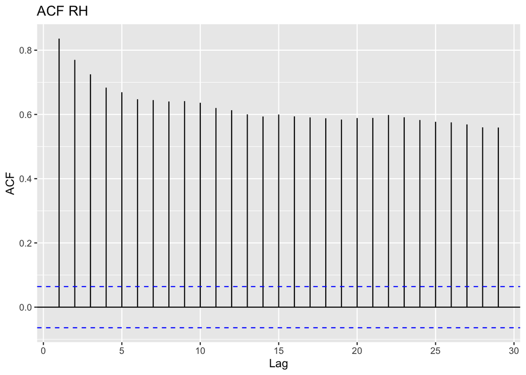

```r
acf_RH <- ggAcf(train_2225$RH) + labs(title = "ACF RH")
acf_RH
```

- Plot ACF RH menurun secara perlahan : RH tidak stasioner

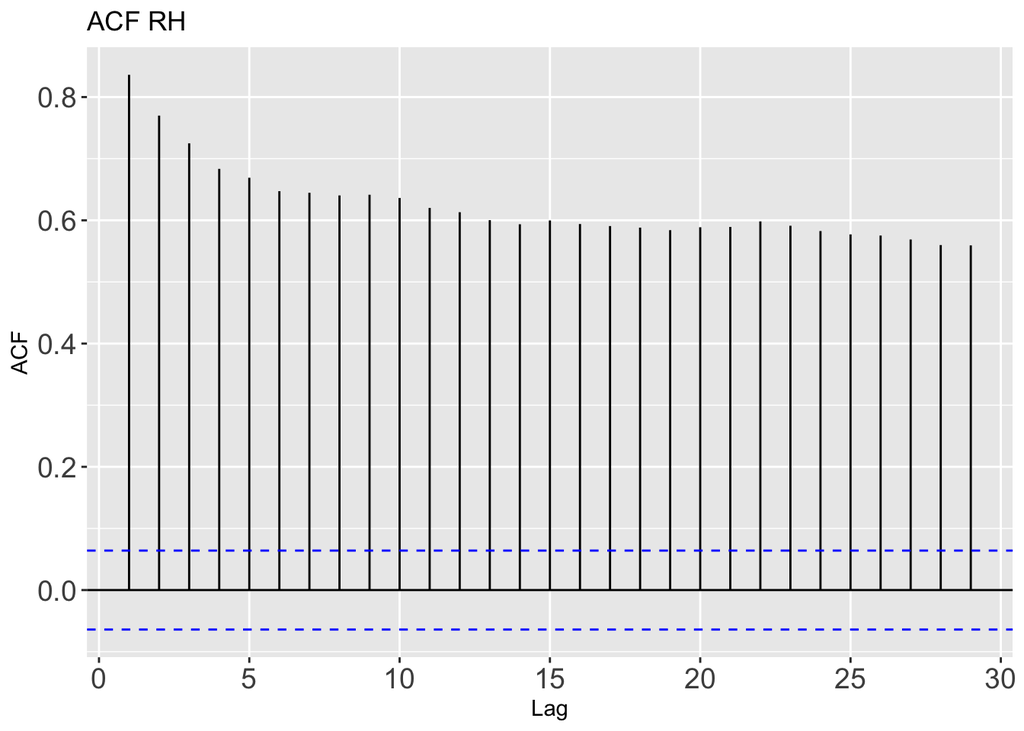

```r
acf_RH <- ggAcf(train_2225$RH) +
  labs(title = "ACF RH") +
  theme(
    axis.text.x = element_text(size = 14),
    axis.text.y = element_text(size = 14)
  )
acf_RH
```

### 5.1.5 Plot ACF WS

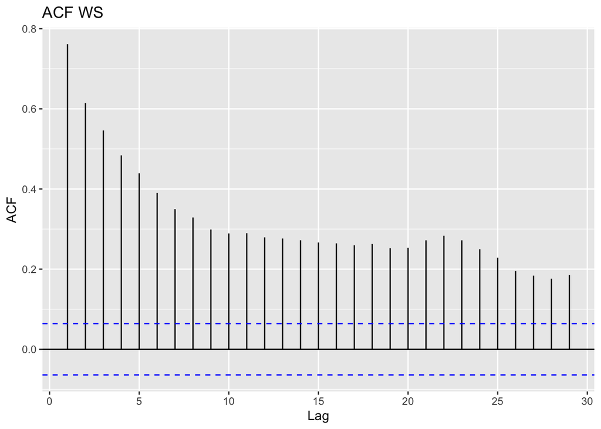

```r
acf_WS <- ggAcf(train_2225$WS) + labs(title = "ACF WS")
acf_WS
```

- Plot ACF WS menurun secara perlahan : WS tidak stasioner

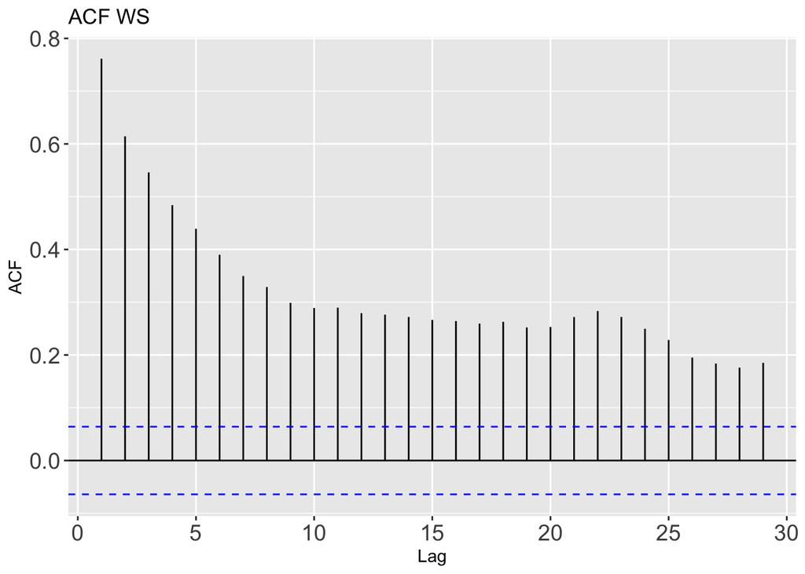

```r
acf_WS <- ggAcf(train_2225$WS) +
  labs(title = "ACF WS") +
  theme(
    axis.text.x = element_text(size = 14),
    axis.text.y = element_text(size = 14)
  )
acf_WS
```

### 5.1.6 Plot ACF Gabungan

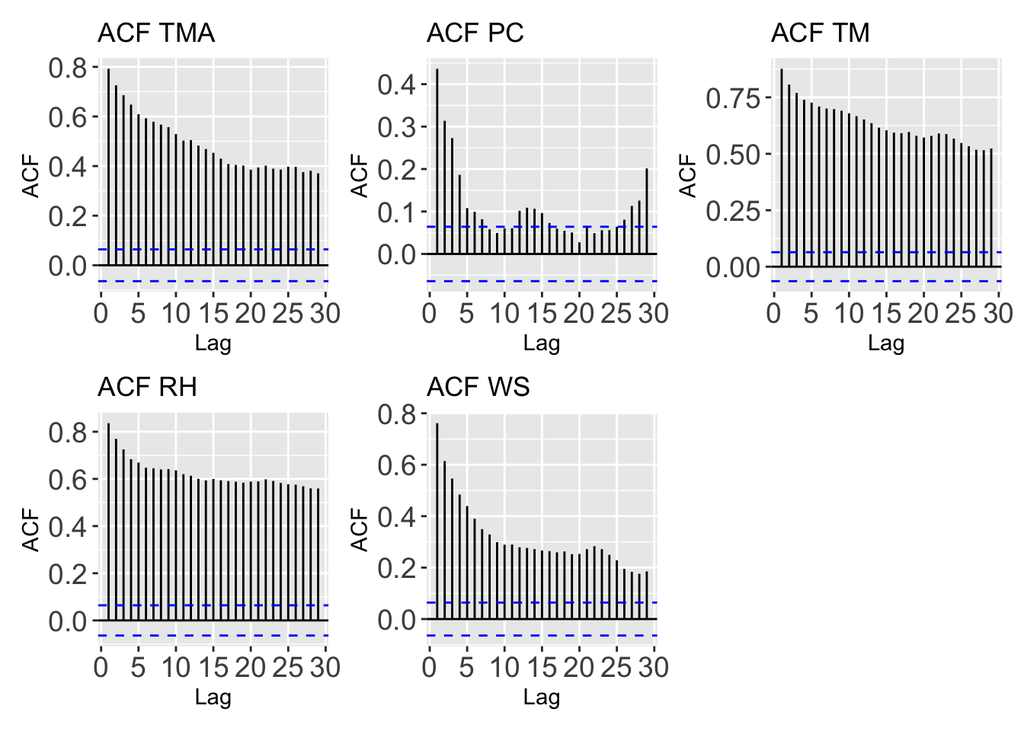

```r
combined_acf <- acf_TMA + acf_PC + acf_TM + acf_RH + acf_WS
combined_acf
```

## 5.2 Plot PACF

### 5.2.1 Plot PACF TMA

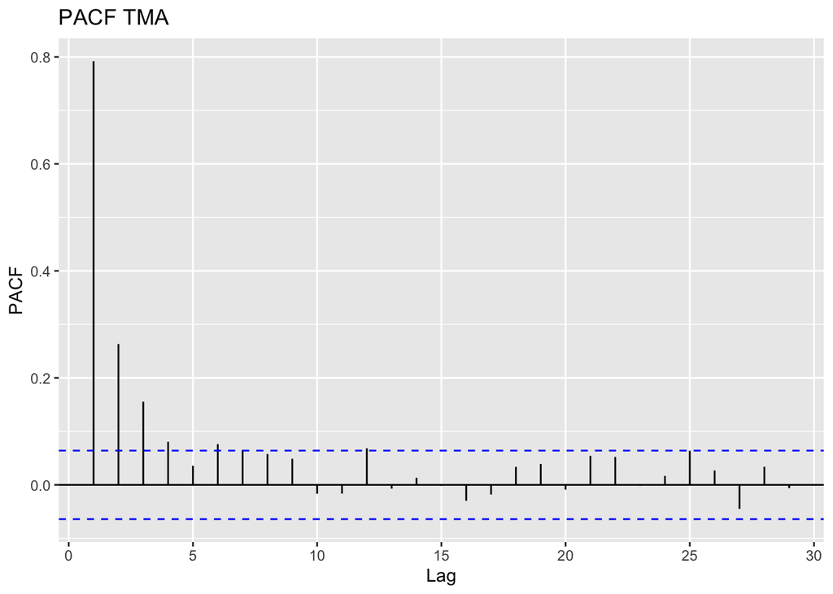

```r
pacf_TMA <- ggPacf(train_2225$TMA) + labs(title = "PACF TMA")
pacf_TMA
```

### 5.2.2 Plot PACF PC

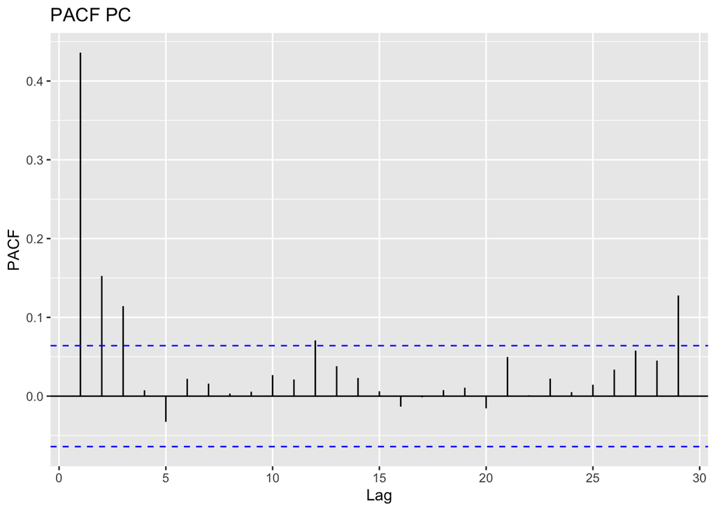

```r
pacf_PC <- ggPacf(train_2225$PC) + labs(title = "PACF PC")
pacf_PC
```

### 5.2.3 Plot PACF TM

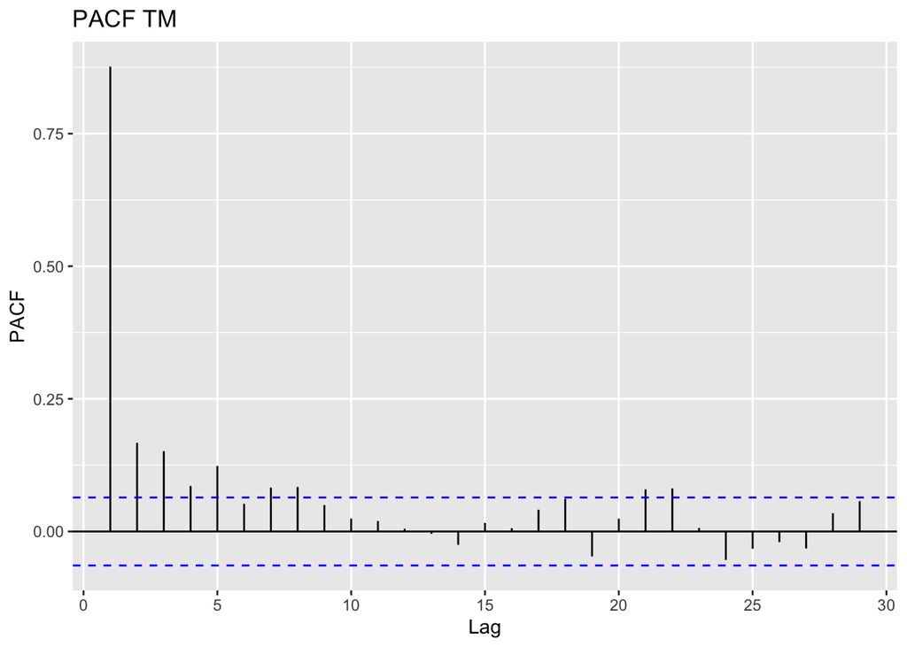

```r
pacf_TM <- ggPacf(train_2225$TM) + labs(title = "PACF TM")
pacf_TM
```

### 5.2.4 Plot PACF RH

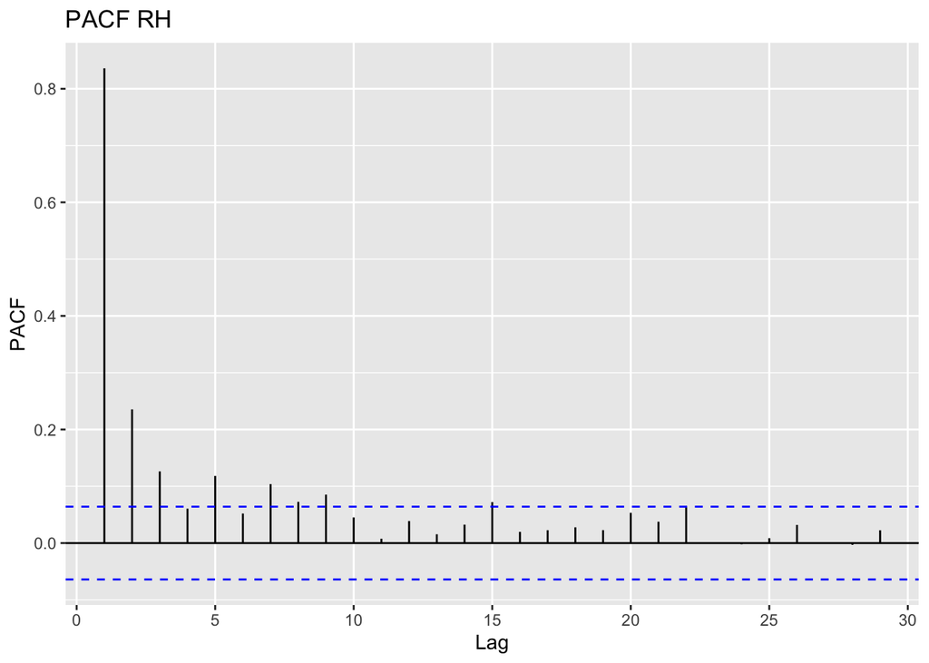

```r
pacf_RH <- ggPacf(train_2225$RH) + labs(title = "PACF RH")
pacf_RH
```

### 5.2.5 Plot PACF WS

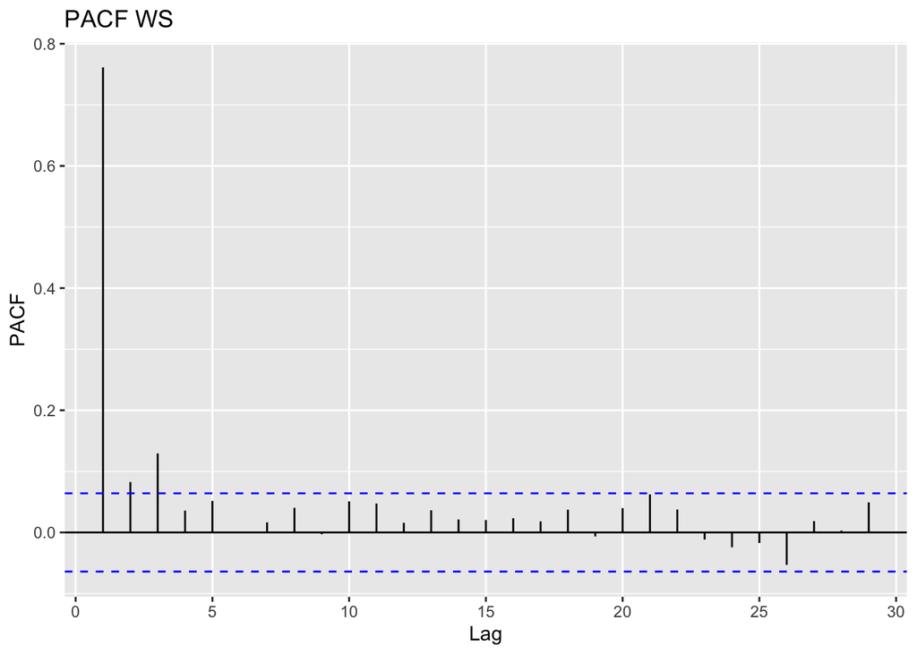

```r
pacf_WS <- ggPacf(train_2225$WS) + labs(title = "PACF WS")
pacf_WS
```

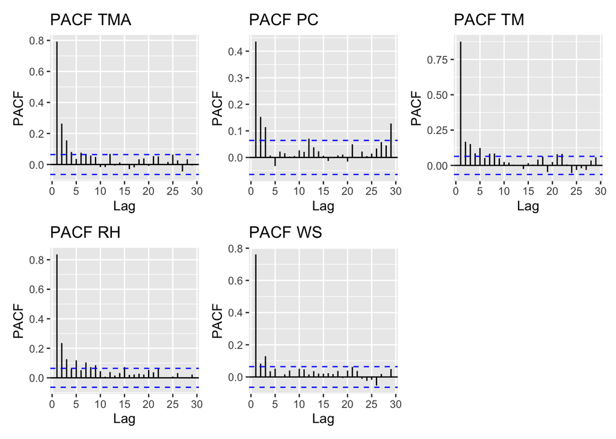

```r
combined_pacf <- pacf_TMA + pacf_PC + pacf_TM + pacf_RH + pacf_WS
combined_pacf
```

## 5.3 Uji ADF

### 5.3.1 Uji ADF TMA

```r
adf.test(train_2225$TMA)
```

```
##
##  Augmented Dickey-Fuller Test
##
## data:  train_2225$TMA
## Dickey-Fuller = -4.0015, Lag order = 9, p-value = 0.01
## alternative hypothesis: stationary
```

- TMA stasioner secara uji formal

### 5.3.2 Uji ADF PC

```r
adf.test(train_2225$PC)
```

```
##
##  Augmented Dickey-Fuller Test
##
## data:  train_2225$PC
## Dickey-Fuller = -7.5589, Lag order = 9, p-value = 0.01
## alternative hypothesis: stationary
```

- PC stasioner secara uji formal

### 5.3.3 Uji ADF TM

```r
adf.test(train_2225$TM)
```

```
##
##  Augmented Dickey-Fuller Test
##
## data:  train_2225$TM
## Dickey-Fuller = -3.5022, Lag order = 9, p-value = 0.04209
## alternative hypothesis: stationary
```

- TM stasioner secara uji formal

### 5.3.4 Uji ADF RH

```r
adf.test(train_2225$RH)
```

```
##
##  Augmented Dickey-Fuller Test
##
## data:  train_2225$RH
## Dickey-Fuller = -3.3561, Lag order = 9, p-value = 0.06101
## alternative hypothesis: stationary
```

- RH tidak stasioner secara uji formal

### 5.3.5 Uji ADF WS

```r
adf.test(train_2225$WS)
```

```
##
##  Augmented Dickey-Fuller Test
##
## data:  train_2225$WS
## Dickey-Fuller = -5.6741, Lag order = 9, p-value = 0.01
## alternative hypothesis: stationary
```

- WS stasioner secara uji formal

## 5.4 Plot CCF

### 5.4.1 Plot CCF TMA dan PC

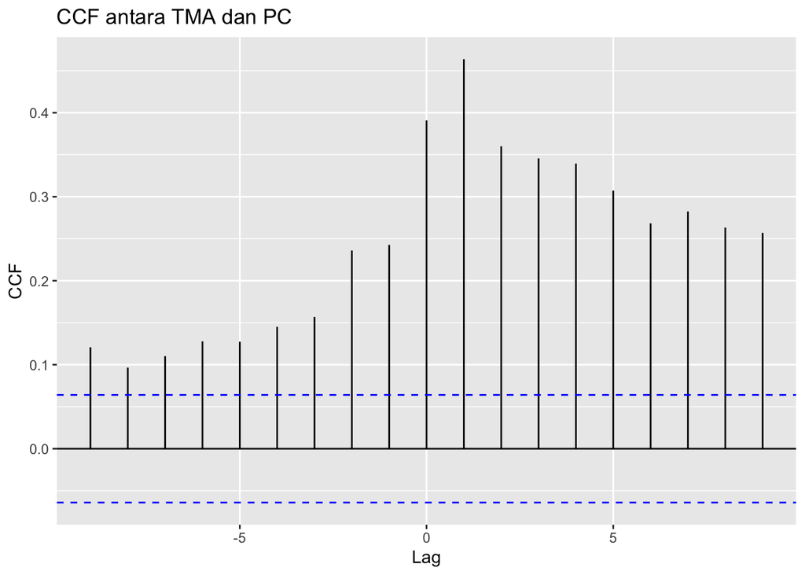

```r
ccf_result1 <- ggCcf(train_2225$TMA, train_2225$PC, lag.max=9)+ggtitle("CCF antara TMA dan PC")
ccf_result1
```